# 03-Web-Setting

## Check IP and Gateway

- `ipconfig`: Check both ip address for host and virtual machine (Windows)
- `ifconfig`: Check both ip address for host and virtual machine (Linux)

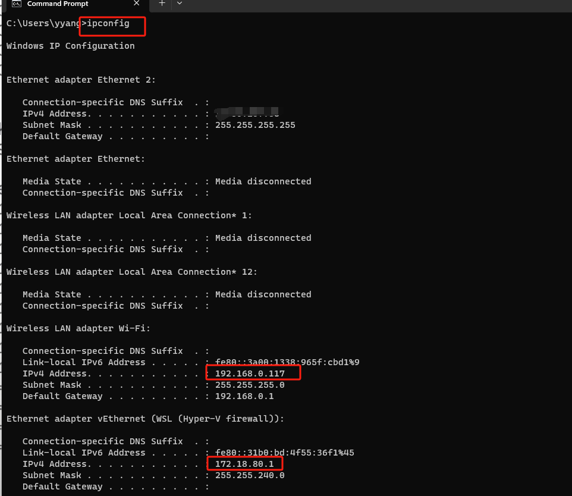

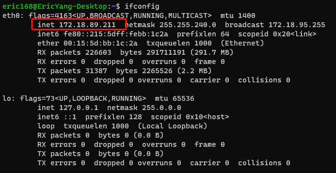

- `ping + [Target ip]` : Check the connection between host and virtual machine

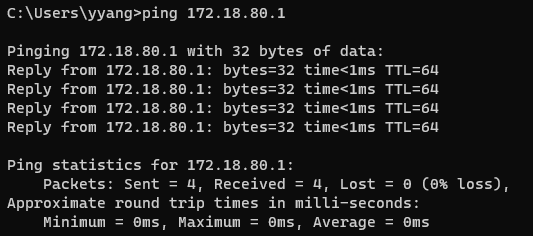

## Bridged vs Network Address Translation (NAT) vs Host

### Bridged Mode

- Bridged mode allows the virtual machine to **appear as a separate device on the host network**.
- It's as if the **virtual machine has its own network adapter and IP address**, independent of the host.
- Bridged mode is suitable for scenarios where you need the virtual machine to be fully visible and accessible on the network, such as **running server applications** that need to be reachable from other devices.

[figure not shown]

- **Advantages**
  - Virtual machines in bridged mode can communicate directly with other devices on the network, including other virtual machines and physical machines.
- **Disadvantages**
  - Bridged mode **requires assigning IP address** to virtual machine
  - Since virtual machines in bridged mode appear as separate devices on the network, they are susceptible to the same **security risks** as physical machines.

### Network Address Translation (NAT)

- NAT mode allows the **virtual machine to share the host's IP address** for outbound connections
- while incoming traffic is routed to the virtual machine based on port forwarding rules.
- NAT mode is suitable for scenarios where you need **internet connectivity for the virtual machine but don't require direct inbound access from the network**, such as browsing the web or downloading updates.

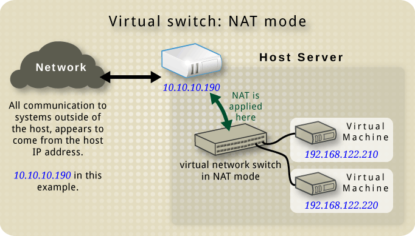

- **Advantages**
  - NAT mode provides internet connectivity to virtual machines **without needing multiple public IP addresses**. (created a local network)
  - It adds an **extra layer of security** by hiding the virtual machine's IP address behind the host's IP address.
- **Disadvantages**
  - External network can not access the virtual machine directly.

### Host-Only Mode

- Created a private network between host and virtual machine, can not access the external network.

## Change to Static IP

### Why we need static IP instead of dynamic?

1. In a server mode, we do want to dynamically assign device IP address, we want every node (**especially the virtual machine**, since we need access them very often through the host) have a static IP for testing and maintenance purpose.

### Change the Internet configuration file in Linux

0. `su`: activate superuser authority
1. `vim etc/sysconfig/network-scripts/ifcfg-ens33`

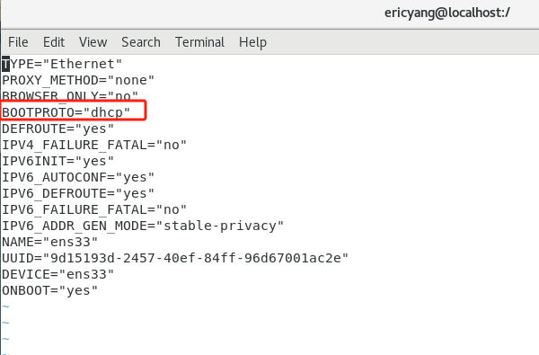

2. Change BootProTO from `dhcp` to `static`
3. Add information about IP, Gateway and DNS
   - `IPADDR = [Your wanted IP address]`
   - `GATEWAY = [Your wanted Gateway address]`
   - `DNS1 = [Your wanted DNS address]`

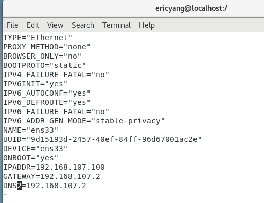

4. reset the network service to activate our setting
   - `service network restart`

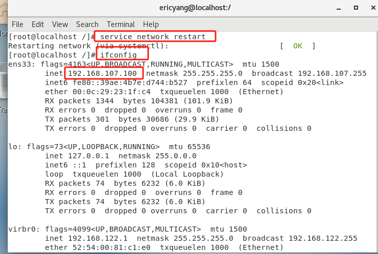

5. ping to check if the network is working

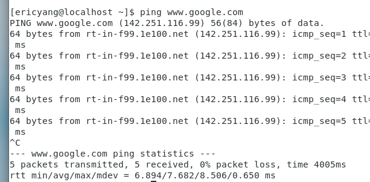

## Change the host name

- Give every node a better memorable name is much convenient than access using IP address
- `hostname` : return the current host name
1. change hostname config file
   - `vim /etc/hostname` : access the config file to change the hostname
2. change hostname using built-in tool
   - `hostnamectl set-hostname "[your hostname]"`

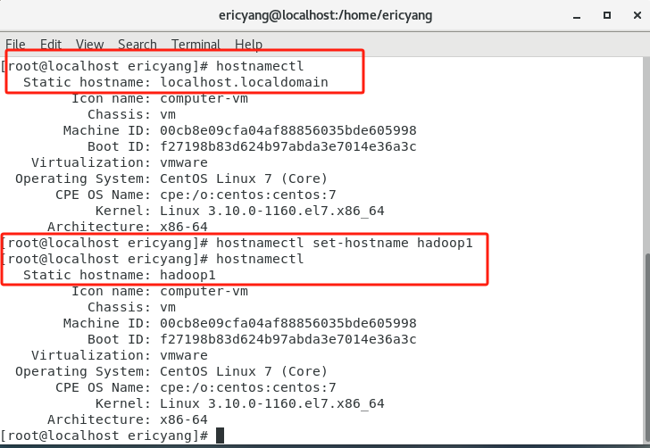

## Save hostname and corresponding IP to config file

1. `vim /etc/hosts` : get into the config file

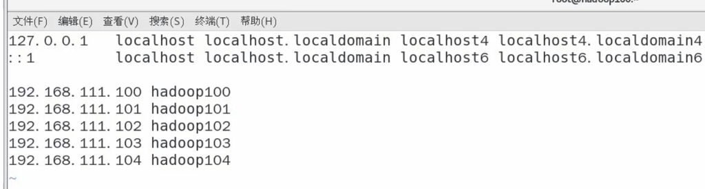

2. Change the host file in Windows as well
   - find the config file
   - add node name and IP

[figure not shown]

## Connect host / node using SSH / Xshell

1. Connect to node
   - `ssh [user name]@[node name]`
   - Use Xshell
2. [Transfer file](https://www.geeksforgeeks.org/scp-command-in-linux-with-examples/#)
   - `scp [options] [user@]host1:]source_file_or_directory ... [[user@]host2:]destination`
   - Use Xftp

[figure not shown]

2025-09-18 2025-09-18